# 关于帕尔默企鹅数据集的探索

- 此次数据集空值的处理，根据数据的情况，通过初步分析，直接进行了删除处理，不做填充；
- 此次数据集的探索，对于数据相关性的可视化，增加使用散点图和线性斜率辅助分析；
- 对于特征差异，主要使用散点图进行可视化分析；
- 在机器学习中，回顾了机器模型选取的基础方法，根据数据集的不同，选择不同的模型评判指标；
- 此次机器学习过程中，不涉及参数调整，直接使用默认参数进行建模；
- 关于聚类分析，做一个尝试。

### 1 导入包

```python
import pandas as pd
import numpy as np
import seaborn as sns
import matplotlib.pyplot as plt
import scipy.stats as stats

from sklearn.preprocessing import LabelEncoder
from sklearn import metrics, model_selection
from sklearn.model_selection import train_test_split
from sklearn.linear_model import LogisticRegression
from sklearn.tree import DecisionTreeClassifier
from sklearn.ensemble import RandomForestClassifier
from sklearn.metrics import recall_score, accuracy_score, precision_score, f1_score
from sklearn.decomposition import PCA
from sklearn.cluster import KMeans
from sklearn.metrics import silhouette_score

import warnings
warnings.filterwarnings('ignore')
```

### 2 数据预处理

```python
df = pd.read_csv('penguins_size.csv')
```

```python
df.head()
```

|  | species | island | culmen_length_mm | culmen_depth_mm | flipper_length_mm | body_mass_g | sex |
| --- | --- | --- | --- | --- | --- | --- | --- |
| 0 | Adelie | Torgersen | 39.1 | 18.7 | 181.0 | 3750.0 | MALE |
| 1 | Adelie | Torgersen | 39.5 | 17.4 | 186.0 | 3800.0 | FEMALE |
| 2 | Adelie | Torgersen | 40.3 | 18.0 | 195.0 | 3250.0 | FEMALE |
| 3 | Adelie | Torgersen | NaN | NaN | NaN | NaN | NaN |
| 4 | Adelie | Torgersen | 36.7 | 19.3 | 193.0 | 3450.0 | FEMALE |

```python
df.info()
```

```
<class 'pandas.core.frame.DataFrame'>
RangeIndex: 344 entries, 0 to 343
Data columns (total 7 columns):
 #   Column             Non-Null Count  Dtype
---  ------             --------------  -----
 0   species            344 non-null    object
 1   island             344 non-null    object
 2   culmen_length_mm   342 non-null    float64
 3   culmen_depth_mm    342 non-null    float64
 4   flipper_length_mm  342 non-null    float64
 5   body_mass_g        342 non-null    float64
 6   sex                334 non-null    object
dtypes: float64(4), object(3)
memory usage: 18.9+ KB
```

```python
df.isnull().sum()
```

```
species               0
island                0
culmen_length_mm      2
culmen_depth_mm       2
flipper_length_mm     2
body_mass_g           2
sex                  10
dtype: int64
```

```python
# 这里我们看到有空值的字段，内容占比较低，这里考虑直接删除
df = df.dropna()
df.isnull().sum()
```

```
species              0
island               0
culmen_length_mm     0
culmen_depth_mm      0
flipper_length_mm    0
body_mass_g          0
sex                  0
dtype: int64
```

```python
df.describe()
```

|  | culmen_length_mm | culmen_depth_mm | flipper_length_mm | body_mass_g |
| --- | --- | --- | --- | --- |
| count | 334.000000 | 334.000000 | 334.000000 | 334.000000 |
| mean | 43.994311 | 17.160479 | 201.014970 | 4209.056886 |
| std | 5.460521 | 1.967909 | 14.022175 | 804.836129 |
| min | 32.100000 | 13.100000 | 172.000000 | 2700.000000 |
| 25% | 39.500000 | 15.600000 | 190.000000 | 3550.000000 |
| 50% | 44.500000 | 17.300000 | 197.000000 | 4050.000000 |
| 75% | 48.575000 | 18.700000 | 213.000000 | 4793.750000 |
| max | 59.600000 | 21.500000 | 231.000000 | 6300.000000 |

```python
df.describe(include='object')
```

|  | species | island | sex |
| --- | --- | --- | --- |
| count | 334 | 334 | 334 |
| unique | 3 | 3 | 3 |
| top | Adelie | Biscoe | MALE |
| freq | 146 | 164 | 168 |

```python
# 这里看到sex竟然有三种，这里需要查看下
df['sex'].unique().tolist()
```

```
['MALE', 'FEMALE', '.']
```

```python
df[df['sex']=='.']
```

|  | species | island | culmen_length_mm | culmen_depth_mm | flipper_length_mm | body_mass_g | sex |
| --- | --- | --- | --- | --- | --- | --- | --- |
| 336 | Gentoo | Biscoe | 44.5 | 15.7 | 217.0 | 4875.0 | . |

```python
# 这里也直接过滤
df = df[df['sex'] != '.']
df.describe(include='object')
```

|  | species | island | sex |
| --- | --- | --- | --- |
| count | 333 | 333 | 333 |
| unique | 3 | 3 | 2 |
| top | Adelie | Biscoe | MALE |
| freq | 146 | 163 | 168 |

### 3 种类分布：不同企鹅种类的分布情况如何？它们在不同岛屿上的分布有何差异？

```python
def fun_distribution(df, column, hue=""):
    plt.figure(figsize=(8, 6))
    plt.title(f'{column} distribution')
    sns.set_palette('Set1')
    if hue:
        ax = sns.countplot(x=column, hue=hue, data=df)
    else:
        ax = sns.countplot(x=column, data=df)

    # 添加百分比标签
    total = len(df)  # 总数
    for p in ax.patches:
        height = p.get_height()
        percentage = f'{height/total*100:.1f}%'
        x = p.get_x() + p.get_width() / 2
        y = height + 1
        ax.annotate(percentage, (x, y), ha='center')

    ax.set_xlabel(column, fontsize=16)
    ax.set_ylabel('Count', fontsize=16)
    ax.tick_params(axis='both', which='major', labelsize=16)
    plt.legend(title=hue)
    plt.show()
```

```
No artists with labels found to put in legend.  Note that artists whose label start with an underscore are ignored when legend() is called with no argument.
```

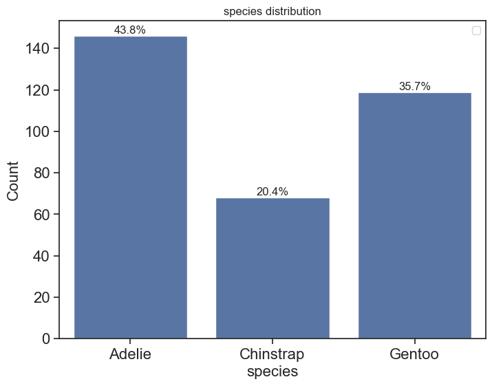

```python
column = 'species'
fun_distribution(df,column)
```

- 帽带企鹅数量最少，阿德利企鹅最多。

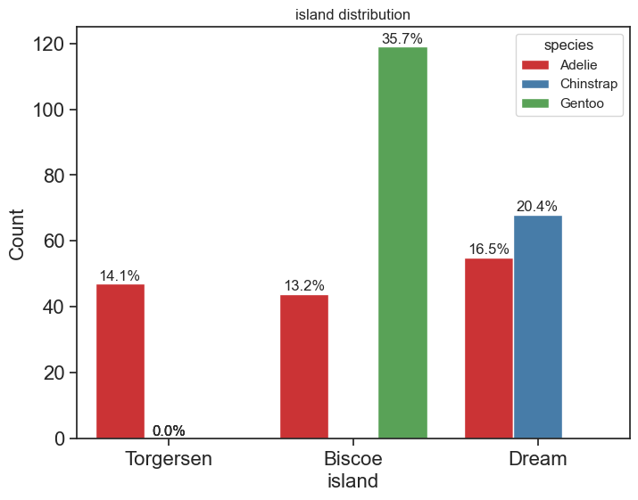

```python
column = 'island'
hue = 'species'
fun_distribution(df,column,hue)
```

### 4 身体测量特征的关系：企鹅的喙长、喙深、鳍状肢长度和体重之间是否存在显著的相关关系？

```python
df_body = df[['culmen_length_mm','culmen_depth_mm','flipper_length_mm','body_mass_g']]
```

```python
correlation_matrix = df_body.corr()
correlation_matrix
```

|  | culmen_length_mm | culmen_depth_mm | flipper_length_mm | body_mass_g |
| --- | --- | --- | --- | --- |
| culmen_length_mm | 1.000000 | -0.228626 | 0.653096 | 0.589451 |
| culmen_depth_mm | -0.228626 | 1.000000 | -0.577792 | -0.472016 |
| flipper_length_mm | 0.653096 | -0.577792 | 1.000000 | 0.872979 |
| body_mass_g | 0.589451 | -0.472016 | 0.872979 | 1.000000 |

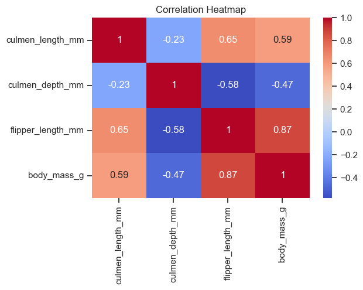

```python
plt.figure(figsize=(6, 4))
sns.heatmap(correlation_matrix, annot=True, cmap='coolwarm')

plt.title('Correlation Heatmap')
plt.show()
```

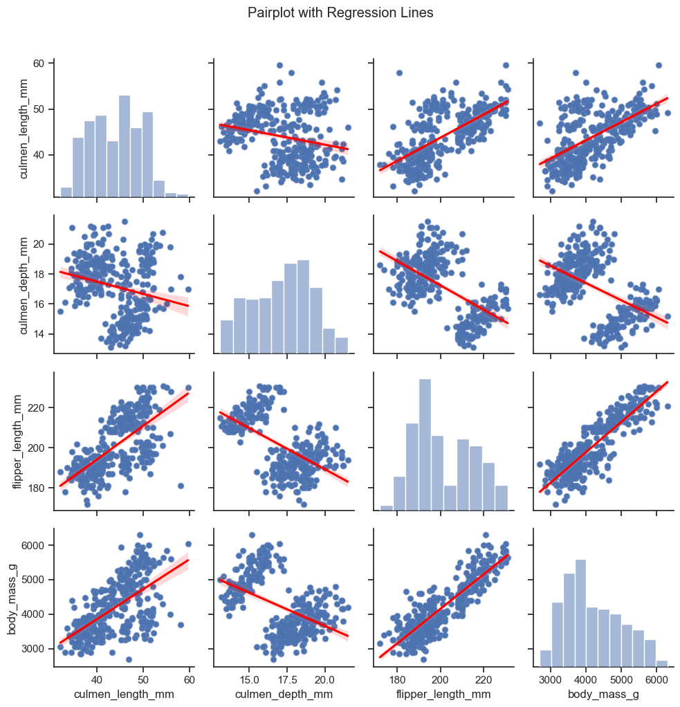

```python
def add_regression_line(x, y, **kwargs):
    sns.regplot(x=x, y=y, scatter_kws={'alpha':0.5}, line_kws={'color':'red'})

sns.set(style="ticks")
pairplot = sns.pairplot(df_body, diag_kws={'alpha':0.5})
pairplot.map_offdiag(add_regression_line)
plt.suptitle("Pairplot with Regression Lines", y=1.02)
plt.tight_layout()
plt.show()
```

```python
result_list = []
for column in df_body.columns.tolist():
    if column != 'body_mass_g':  # 确保我们不与自身计算相关性
        p_value = stats.pearsonr(df_body[column], df_body['body_mass_g'])[1]
        result_list.append({'Column': column, 'P-value': p_value})

result_df = pd.DataFrame(result_list)
result_df
```

|  | Column | P-value |
| --- | --- | --- |
| 0 | culmen_length_mm | 1.538614e-32 |
| 1 | culmen_depth_mm | 7.024160e-20 |
| 2 | flipper_length_mm | 3.132836e-105 |

- 通过上面相关性系数和散点图分布的情况，以及P值的情况：

-企鹅的喙长与体重之间存在显著相关关系，且相关性处于中间水平。这意味着喙长和体重之间存在一定的线性关系，但相关性程度不是非常强。  
-企鹅的喙的深度与体重之间也存在显著相关关系，但相关性处于最低水平。这表示喙的深度和体重之间的线性关系较弱。  
-企鹅的鳍状肢的长度与体重之间存在显著相关关系，并且相关性处于最高水平。这意味着鳍状肢的长度和体重之间的线性关系非常强。

### 5 种类特征差异：不同种类的企鹅在体重、喙长、喙深和鳍状肢长度上有何差异？

```python
df_species = df[['species','culmen_length_mm','culmen_depth_mm','flipper_length_mm','body_mass_g']]
```

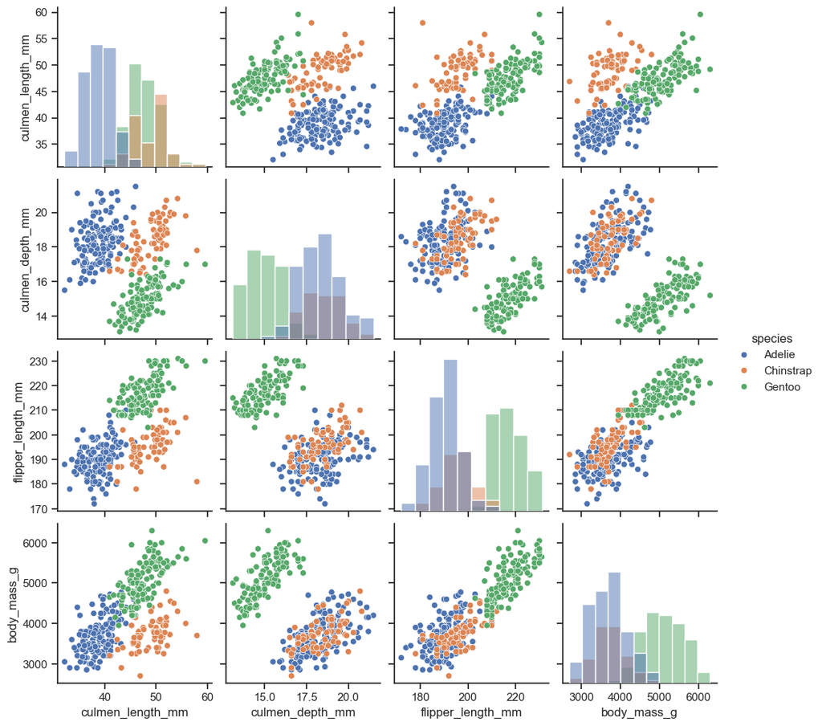

```python
sns.pairplot(df_species, hue = 'species',diag_kws={'alpha':0.5}, diag_kind='hist')
```

### 6 性别差异：在体重和身体测量特征上，雄性企鹅和雌性企鹅之间是否存在显著差异？

```python
df_sex = df[['sex','culmen_length_mm','culmen_depth_mm','flipper_length_mm','body_mass_g']]
```

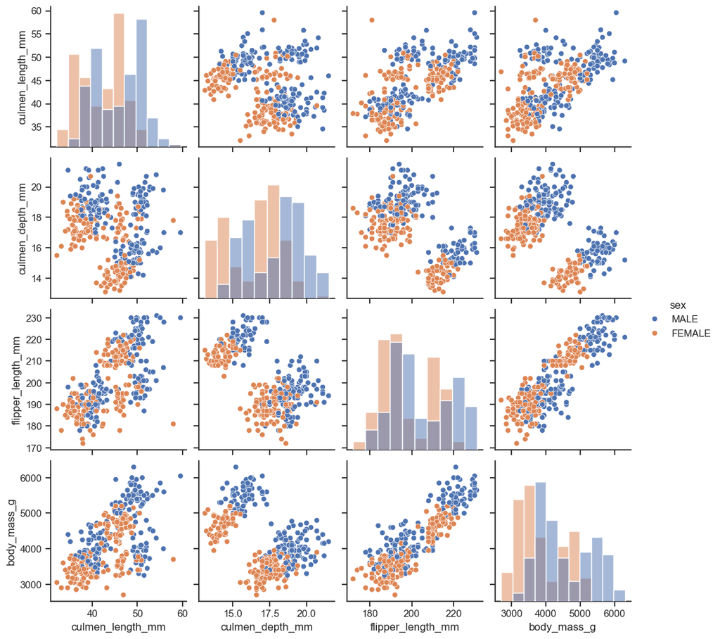

```python
sns.pairplot(df_sex, hue = 'sex',diag_kws={'alpha':0.5}, diag_kind='hist')
```

- 在不做企鹅类别的细分情况整体来看，雄性企鹅的体重更重，且喙长、喙深和鳍状肢长度也更长更深一些,这表明在这些特征上，雄性企鹅相对于雌性企鹅具有更大的体型。
- 从两两关系特征看，雄性企鹅体型更大一些。喙长和喙深比，喙长、喙深和鳍状肢长度的比例，雄性和雌性都基本相似。

### 7 岛屿影响：不同岛屿上的企鹅在身体测量特征上有无显著差异？

```python
df_island = df[['island','culmen_length_mm','culmen_depth_mm','flipper_length_mm','body_mass_g']]
```

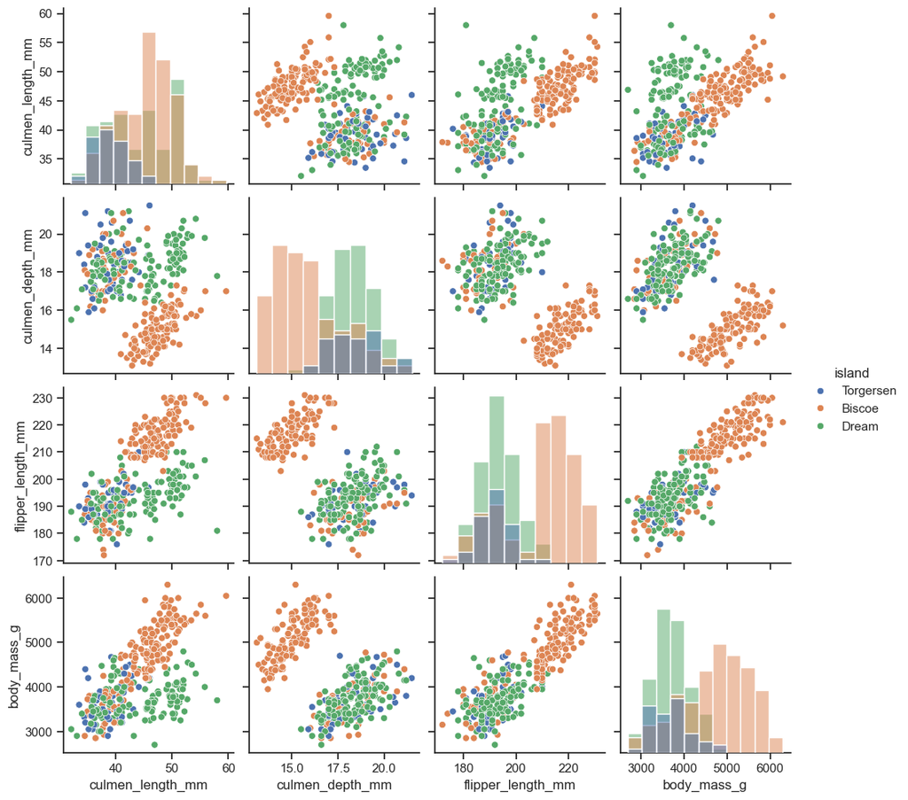

```python
sns.pairplot(df_island, hue = 'island',diag_kws={'alpha':0.5}, diag_kind='hist')
```

### 8 可以使用哪些机器学习模型（如逻辑回归、决策树、随机森林等）来预测企鹅的种类或性别？

```python
encoder = LabelEncoder()
df['species'] = encoder.fit_transform(df['species'])
df['island'] = encoder.fit_transform(df['island'])
df['sex'] = encoder.fit_transform(df['sex'])
```

```python
# 添加特征
df['culmen_length_depth'] = df['culmen_length_mm']+df['culmen_depth_mm']
df['culmen_length_flipper'] = df['culmen_length_mm']+df['flipper_length_mm']
df['culmen_depth_flipper'] = df['culmen_depth_mm']+df['flipper_length_mm']

df['culmen_length_mass'] = df['culmen_length_mm']+df['body_mass_g']
df['culmen_depth_mm'] = df['culmen_depth_mm']+df['body_mass_g']
df['flipper_length_mm'] = df['culmen_depth_mm']+df['body_mass_g']

df['flipper_length_mm'] = df['culmen_depth_mm']+df['body_mass_g']
```

```python
df.info()
```

```
<class 'pandas.core.frame.DataFrame'>
Index: 333 entries, 0 to 343
Data columns (total 11 columns):
 #   Column                 Non-Null Count  Dtype
---  ------                 --------------  -----
 0   species                333 non-null    int32
 1   island                 333 non-null    int32
 2   culmen_length_mm       333 non-null    float64
 3   culmen_depth_mm        333 non-null    float64
 4   flipper_length_mm      333 non-null    float64
 5   body_mass_g            333 non-null    float64
 6   sex                    333 non-null    int32
 7   culmen_length_depth    333 non-null    float64
 8   culmen_length_flipper  333 non-null    float64
 9   culmen_depth_flipper   333 non-null    float64
 10  culmen_length_mass     333 non-null    float64
dtypes: float64(8), int32(3)
memory usage: 27.3 KB
```

- 模型评估方法

参考：https://zhuanlan.zhihu.com/p/514339562

metrics.classification_report函数生成的评估报告包含以下指标：

Precision（精确率）：预测为正类的样本中，真正为正类的比例。即 TP / (TP + FP)。  
Recall（召回率）：真正为正类的样本中，被正确预测为正类的比例。即 TP / (TP + FN)。  
F1-score（F1值）：综合考虑了精确率和召回率的指标，是二者的调和平均值。即 2 * (precision * recall) / (precision + recall)。  
Support（支持数）：每个类别的样本数量。  
Accuracy（准确率）：所有样本中被正确分类的比例。即 (TP + TN) / (TP + TN + FP + FN)。

- 模型选择时，指标判断依据：
- Accuracy > acc_cv > f1-score
- f1-score 使用加权平均值进行对比，weighted avg

```python
# 这里只做三个模型的对比：逻辑回归，决策树，随机森林，参数均不做调参
# 获取 训练集的预测结果，测试集的预测结果，模型在测试集上的准确率，交叉验证的准确率，测试集样本属于正类的概率
def fit_ml_algo(algo, X_train, y_train, X_test, y_test, cv):
    '''
    algo:算法实例
    '''
    model = algo.fit(X_train, y_train)
    test_pred = model.predict(X_test)
    if (isinstance(algo, (LogisticRegression,
                          DecisionTreeClassifier,
                          RandomForestClassifier))):
        probs = model.predict_proba(X_test)[:,1] # 测试集样本属于正类的概率
    else:
        probs = "Not Available"
    acc = round(model.score(X_test, y_test) * 100, 2)  # 准确率
    # CV
    train_pred = model_selection.cross_val_predict(algo,
                                                  X_train,
                                                  y_train,
                                                  cv=cv,
                                                  n_jobs = -1)
    acc_cv = round(metrics.accuracy_score(y_train, train_pred) * 100, 2) # 交叉验证的准确率
    return train_pred, test_pred, acc, acc_cv, probs
```

```python
import random
random.seed(1)
```